# scRNAseq analysis using Rmarkdown

## 2.5 Scaling the data

Next, we apply a linear transformation (‘scaling’) that is a standard pre-processing step prior to dimensional reduction techniques like PCA. The ScaleData function:

- Shifts the expression of each gene, so that the mean expression across cells is 0
- Scales the expression of each gene, so that the variance across cells is 1
- This step gives equal weight in downstream analyses, so that highly-expressed genes do not dominate
- The results of this are stored in obj[[“RNA”]]@scale.data

```r
all.genes <- rownames(obj)
obj <- ScaleData(obj, features = all.genes)
```

## 2.6 Perform linear dimensional reduction (PCA)

Next we perform PCA on the scaled data. By default, only the previously determined variable features are used as input, but can be defined using features argument if you wish to choose a different subset.

```r
obj <- RunPCA(obj, features = VariableFeatures(object = obj))
```

```
## PC_ 1
## Positive:  BCAT1, RBM47, ST6GAL1, LAMA1, TXNRD1, DAB2, ALPL, psiTPTE22, GLIPR2, ASRGL1
##     S100A10, PVRL2, PI4KAP2, SHMT1, ANXA2, NR2F6, SEMA6A, DHCR24, SLC7A2, AKAP12
##     CTNNAL1, CTSL1, DSG2, SLC2A3, TEAD1, TMC7, KRT18, MALAT1, PLS3, TNS3
## Negative:  FAM46C, THSD7A, PLEKHG1, PDE8B, GNA14, PTK2B, MRC1, USP2, RIMKLA, ADAMTSL1
##     TMEM200A, CREB5, FHOD3, SLCO3A1, DNAH10, KALRN, ZNF618, PRR15, ACAD11, ABCB4
##     LYPD1, CRMP1, PDK1, TMEM163, FBLN7, MCTP1, JAG1, FBLN5, MCTP2, ELOVL4
## PC_ 2
## Positive:  KITLG, BIK, TMEM92, STAG3L2, KHDC1, C6orf204, STAG3L3, GPR155, DRAM1, SLC16A6
##     TESK2, PPP1R3B, HIST1H2BD, C21orf91, HIST1H2BK, GABARAPL1, CCNE1, STX11, ZNF296, KIAA0802
##     YPEL2, NBPF10, CAB39L, HIST2H2BF, ZNF675, STAP2, BAMBI, TCN2, INPP5J, GLS
## Negative:  DNMT3B, MOBKL2B, JUP, GCH1, GAB2, ASAH1, C8orf42, C4orf19, GRHL1, PITPNC1
##     REEP1, PTGR1, RHOC, EFHD1, C9orf140, KRT18, SH2D4A, RHOU, PRSS8, PHKA1
##     SLC1A3, ANXA6, CLDN4, ANXA2, C6orf132, ENPEP, MTHFD1L, CALD1, GATA3, GATA2
## PC_ 3
## Positive:  GYPC, ARHGEF35, LIMCH1, RRAD, IFI16, GPRC5C, PRDM1, MAN1C1, LARP6, MT1G
##     VCAN, TMEM63A, FLRT2, APOC2, GK, APOE, TNFRSF25, CXCL12, SPP1, PMEPA1
##     PRUNE2, TSPAN33, TRIM56, FCGBP, DACT1, MAP4K1, KRTCAP3, TNFRSF8, ARMCX2, MEG3
## Negative:  DAB2, SLC7A2, PVT1, PLCD3, TFRC, CLDN4, EMP2, EFNA1, RAB20, RALGAPA2
##     GATA2, ENPEP, GALNT10, DNAJC6, CTSH, FHL2, SEMA6D, PTGES, TEAD1, TACSTD2
##     GATA3, DLC1, OAF, TMEM56, MAGI3, GPR126, C7orf50, KIAA1161, CEBPA, C19orf21
## PC_ 4
## Positive:  XAF1, PDK4, TNFRSF10C, HOXA5, F5, HCG26, KCNJ2, C6orf174, SEMA3C, CTAGE4
##     CMYA5, PCDH17, CXCR4, GOLGA8B, FAM84A, SLC16A14, FOLR2, HHIPL1, ADCY4, ADAMTS5
##     LCA5, TAP2, ALOX15B, FOXC1, CH25H, RAPGEF5, ACCS, ZNF239, PCDHGA9, SLFN11
## Negative:  FTL, GNA11, CCNE1, PDPR, PTTG1, KANK2, TMEM51, ABTB2, PECAM1, ZNF296
##     C1orf38, STXBP1, GPNMB, ELOVL6, MITF, SLC45A4, PPP1R16B, PLLP, TROAP, PLK1S1
##     BAMBI, TMEM92, BLVRB, CHAC1, ACOT11, GTF2IRD1, STAP2, ITGA5, CACNB3, ZNF395
## PC_ 5
## Positive:  LAX1, PODNL1, MUC1, GBP1, APOBEC3C, APOBEC3G, HCK, SEMA7A, ANKRD34A, NIPSNAP3B
##     CCDC68, PLAU, CDC42BPG, AXL, SPAG4, MYO1G, SGK1, ZKSCAN1, CCRN4L, GPC3
##     STIL, NLGN3, FOS, PLEKHG6, IL1RN, RHOD, TEC, C19orf33, CADM1, GPR19
## Negative:  VPS37D, PDLIM4, C3orf54, LOC100270804, ZNF287, N4BP2L1, FNDC5, ZNF491, WNT2B, BEND5
##     C1QTNF2, SOX18, NUDT12, CARD14, SSC5D, KDR, TYROBP, DENND2C, PCDHGB6, MAGEH1
##     PCDHB14, C11orf45, RIMS3, MFNG, RAB17, RAB37, SH3PXD2B, CDKN2C, RGAG4, CLTCL1
```

## 2.7 Determine the ‘dimensionality’ of the dataset

To overcome the extensive technical noise in any single feature for scRNA-seq data, Seurat clusters cells based on their PCA scores, with each PC essentially representing a ‘metafeature’ that combines information across a correlated feature set. The top principal components therefore represent a robust compression of the dataset. However, how many componenets should we choose to include? 10? 20? 100?

In Macosko et al, we implemented a resampling test inspired by the JackStraw procedure. We randomly permute a subset of the data (1% by default) and rerun PCA, constructing a ‘null distribution’ of feature scores, and repeat this procedure. We identify ‘significant’ PCs as those who have a strong enrichment of low p-value features.

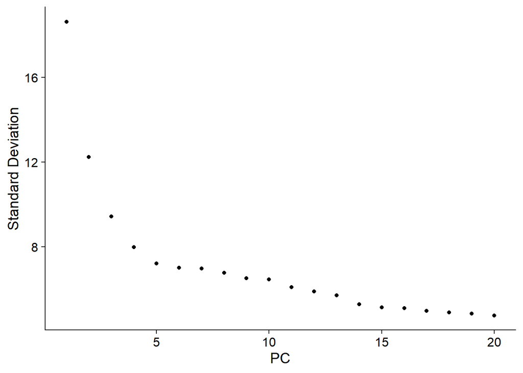

```r
ElbowPlot(obj)
```

## 2.8 Cluster the cells

Seurat v3 applies a graph-based clustering approach, building upon initial strategies in (Macosko et al). Importantly, the distance metric which drives the clustering analysis (based on previously identified PCs) remains the same. However, our approach to partioning the cellular distance matrix into clusters has dramatically improved. Our approach was heavily inspired by recent manuscripts which applied graph-based clustering approaches to scRNA-seq data [SNN-Cliq, Xu and Su, Bioinformatics, 2015] and CyTOF data [PhenoGraph, Levine et al., Cell, 2015]. Briefly, these methods embed cells in a graph structure - for example a K-nearest neighbor (KNN) graph, with edges drawn between cells with similar feature expression patterns, and then attempt to partition this graph into highly interconnected ‘quasi-cliques’ or ‘communities’.

As in PhenoGraph, we first construct a KNN graph based on the euclidean distance in PCA space, and refine the edge weights between any two cells based on the shared overlap in their local neighborhoods (Jaccard similarity). This step is performed using the FindNeighbors function, and takes as input the previously defined dimensionality of the dataset (first 10 PCs).

To cluster the cells, we next apply modularity optimization techniques such as the Louvain algorithm (default) or SLM [SLM, Blondel et al., Journal of Statistical Mechanics], to iteratively group cells together, with the goal of optimizing the standard modularity function. The FindClusters function implements this procedure, and contains a resolution parameter that sets the ‘granularity’ of the downstream clustering, with increased values leading to a greater number of clusters. We find that setting this parameter between 0.4-1.2 typically returns good results for single-cell datasets of around 3K cells. Optimal resolution often increases for larger datasets. The clusters can be found using the Idents function.

```r
obj <- FindNeighbors(obj, dims = 1:10)
obj <- FindClusters(obj, resolution = 0.5)
```

```
## Modularity Optimizer version 1.3.0 by Ludo Waltman and Nees Jan van Eck
##
## Number of nodes: 90
## Number of edges: 1396
##
## Running Louvain algorithm...
## Maximum modularity in 10 random starts: 0.8195
## Number of communities: 3
## Elapsed time: 0 seconds
```

## 2.10 Run non-linear dimensional reduction (UMAP/tSNE)

```r
obj <- RunUMAP(obj, dims = 1:10)
```

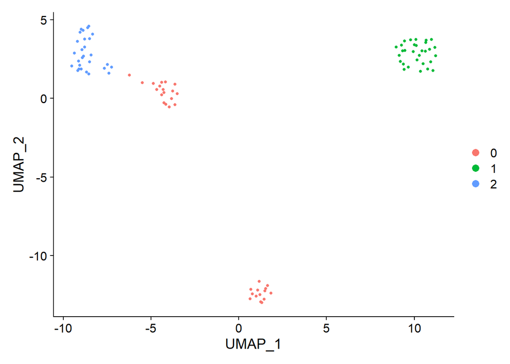

```r
DimPlot(obj, reduction = "umap")
```

## 2.11 Plot UMAP colored by custom metadata

### 2.11.1 UMAP plot colored by cell types

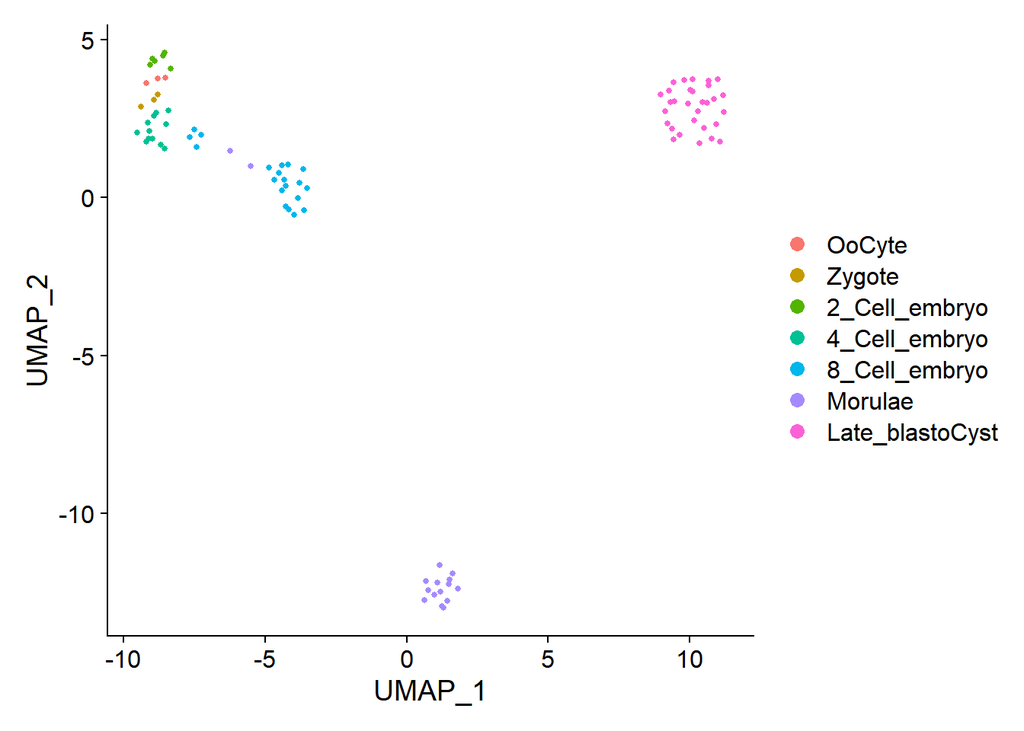

```r
Idents(obj) <- obj$Cluster
DimPlot(obj, reduction = "umap")
```

### 2.11.2 UMAP plot colored by time

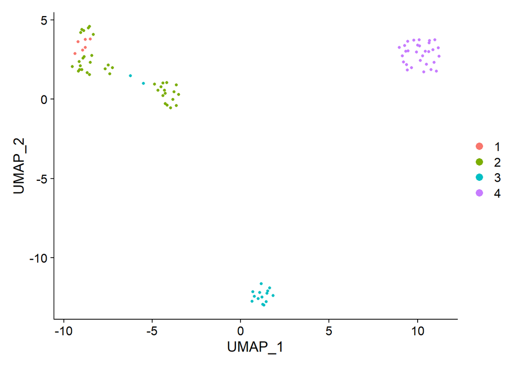

```r
Idents(obj) <- obj$Time
DimPlot(obj, reduction = "umap")
```

### 2.11.3 UMAP plot colored by condition

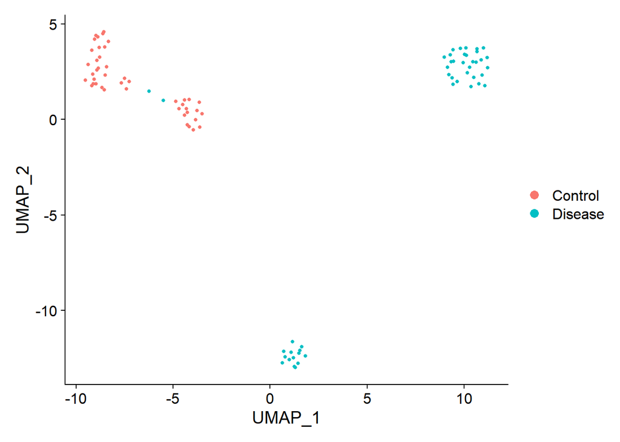

```r
Idents(obj) <- obj$Condition
DimPlot(obj, reduction = "umap")
```

## 2.12 Finding differentially expressed features

Find cell type specific genes between control and disease group

```r
Idents(obj) <- obj$Condition
cts_de_genes <- FindMarkers(obj, ident.1 = "Control", ident.2 = "Disease")

DT::datatable(cts_de_genes, extensions = c('FixedColumns','Buttons'),
              options = list(
                pageLength = 5,
                scrollX = TRUE,
                scrollCollapse = TRUE,
                dom = 'Bfrtip',
                buttons = c('copy', 'csv', 'excel')
              ))
```

|  | p_val | avg_logFC | pct.1 | pct.2 | p_val_adj |
| --- | --- | --- | --- | --- | --- |
| CLEC10A | 2.5920158999418e-18 | 0.653556788605936 | 1 | 0.022 | 8.89839058450019e-15 |
| C11orf41 | 2.3010232199503e-17 | 1.57164033699288 | 1 | 0.087 | 7.89941271408938e-14 |
| TMEM163 | 5.97864060162268e-17 | 2.92578024743659 | 1 | 0.239 | 2.05246731853707e-13 |
| ENG | 1.59501518326185e-16 | 0.738009719611584 | 1 | 0.239 | 5.47568712413792e-13 |
| PDK1 | 2.12034473138172e-16 | 1.12705021092492 | 0.977 | 0.174 | 7.27914346283343e-13 |
| C21orf7 | 2.1418192452916e-16 | 0.686259937497389 | 1 | 0.304 | 7.35286546908607e-13 |
| PDE8B | 2.18593309305742e-16 | 3.7330360983756 | 1 | 0.413 | 7.50430830846612e-13 |
| GDF9 | 2.34271422089698e-16 | 2.3430204016228 | 1 | 0.587 | 8.04253792033934e-13 |
| MRC1 | 3.14322512907254e-16 | 1.2680824824244 | 0.977 | 0.239 | 1.0790691868106e-12 |
| DNAH10 | 3.31158037367375e-16 | 1.76500572323058 | 1 | 0.261 | 1.1368655422822e-12 |

[output cut: 1149 more lines]

### 2.12.1 Violin plot for top 10 DEGs

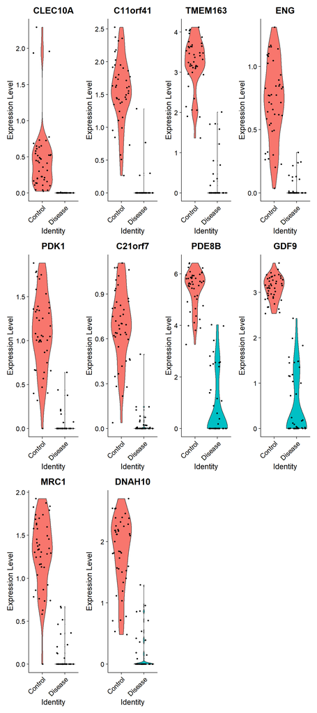